# Risk Factor Analysis

## Outcome Variable

**Outcome Variable:** stunted

## Predictor Variables

**Intervention Variable:** vagbrth

**Adjustment Set:**

unadjusted

## Stratifying Variables

The analysis was stratified on these variable(s):

- agecat
- studyid

The following strata were considered:

- agecat: 12 months, studyid: ki1000108-CMC-V-BCS-2002
- agecat: 12 months, studyid: ki1000108-IRC
- agecat: 12 months, studyid: ki1017093b-PROVIDE
- agecat: 12 months, studyid: ki1017093c-NIH-Crypto
- agecat: 12 months, studyid: ki1066203-TanzaniaChild2
- agecat: 12 months, studyid: ki1126311-ZVITAMBO
- agecat: 18 months, studyid: ki1000108-CMC-V-BCS-2002
- agecat: 18 months, studyid: ki1000108-IRC
- agecat: 18 months, studyid: ki1017093b-PROVIDE
- agecat: 18 months, studyid: ki1017093c-NIH-Crypto
- agecat: 18 months, studyid: ki1066203-TanzaniaChild2
- agecat: 18 months, studyid: ki1126311-ZVITAMBO
- agecat: 24 months, studyid: ki1000108-CMC-V-BCS-2002
- agecat: 24 months, studyid: ki1000108-IRC
- agecat: 24 months, studyid: ki1017093b-PROVIDE
- agecat: 24 months, studyid: ki1017093c-NIH-Crypto
- agecat: 24 months, studyid: ki1066203-TanzaniaChild2
- agecat: 24 months, studyid: ki1126311-ZVITAMBO
- agecat: 3 months, studyid: ki1000108-CMC-V-BCS-2002
- agecat: 3 months, studyid: ki1000108-IRC
- agecat: 3 months, studyid: ki1017093b-PROVIDE
- agecat: 3 months, studyid: ki1017093c-NIH-Crypto
- agecat: 3 months, studyid: ki1066203-TanzaniaChild2
- agecat: 3 months, studyid: ki1126311-ZVITAMBO
- agecat: 6 months, studyid: ki1000108-CMC-V-BCS-2002
- agecat: 6 months, studyid: ki1000108-IRC
- agecat: 6 months, studyid: ki1017093b-PROVIDE
- agecat: 6 months, studyid: ki1017093c-NIH-Crypto
- agecat: 6 months, studyid: ki1066203-TanzaniaChild2
- agecat: 6 months, studyid: ki1126311-ZVITAMBO
- agecat: 9 months, studyid: ki1000108-CMC-V-BCS-2002
- agecat: 9 months, studyid: ki1000108-IRC
- agecat: 9 months, studyid: ki1017093b-PROVIDE
- agecat: 9 months, studyid: ki1017093c-NIH-Crypto
- agecat: 9 months, studyid: ki1066203-TanzaniaChild2
- agecat: 9 months, studyid: ki1126311-ZVITAMBO
- agecat: Birth, studyid: ki1000108-CMC-V-BCS-2002
- agecat: Birth, studyid: ki1000108-IRC
- agecat: Birth, studyid: ki1017093c-NIH-Crypto
- agecat: Birth, studyid: ki1126311-ZVITAMBO

### Dropped Strata

Some strata were dropped due to rare outcomes:

- agecat: Birth, studyid: ki1000108-CMC-V-BCS-2002
- agecat: Birth, studyid: ki1017093c-NIH-Crypto
- agecat: 3 months, studyid: ki1066203-TanzaniaChild2
- agecat: 6 months, studyid: ki1066203-TanzaniaChild2
- agecat: 9 months, studyid: ki1066203-TanzaniaChild2
- agecat: 12 months, studyid: ki1066203-TanzaniaChild2
- agecat: 18 months, studyid: ki1066203-TanzaniaChild2
- agecat: 24 months, studyid: ki1066203-TanzaniaChild2
- agecat: 24 months, studyid: ki1126311-ZVITAMBO

## Methods Detail

We’re interested in the causal parameters $E[Y_a]$ for all values of $a \in \mathcal{A}$. These parameters represent the mean outcome if, possibly contrary to fact, we intervened to set all units to have $A=a$. Under the randomization and positivity assumptions, these are identified by the statistical parameters $\psi_a=E_W[E_{Y|A,W}(Y|A=a,W)]$. In addition, we’re interested in the mean of $Y$, $E[Y]$ under no intervention (the observed mean). We will estimate these parameters by using SuperLearner to fit the relevant likelihood factors – $E_{Y|A,W}(Y|A=a,W)$ and $p(A=a|W)$, and then updating our likelihood fit using a joint TMLE.

For unadjusted analyses ($W=\{\}$), initial likelihoods were estimated using Lrnr_glm to estimate the simple $E(Y|A)$ and Lrnr_mean to estimate $p(A)$. For adjusted analyses, a small library containing Lrnr_glmnet, Lrnr_xgboost, and Lrnr_mean was used.

Having estimated these parameters, we will then use the delta method to estimate relative risks and attributable risks relative to a prespecified baseline level of $A$.

# Results Detail

## Results Plots

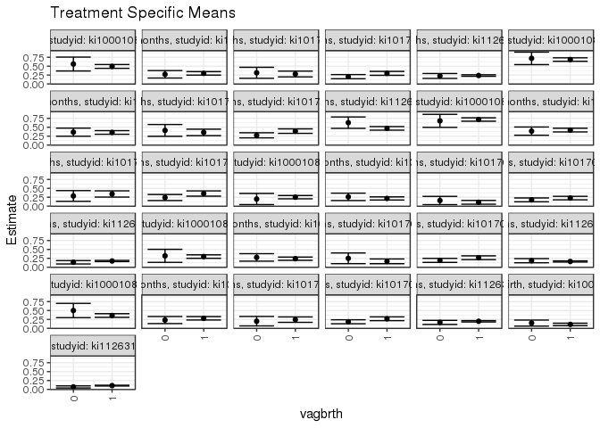

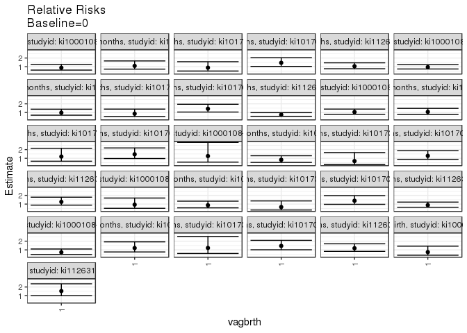

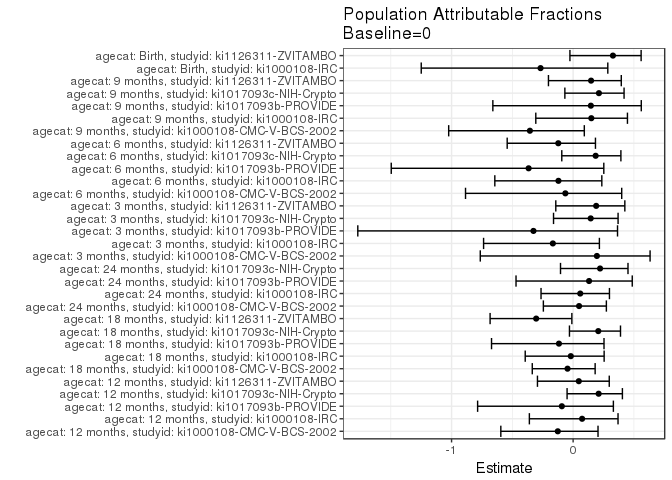

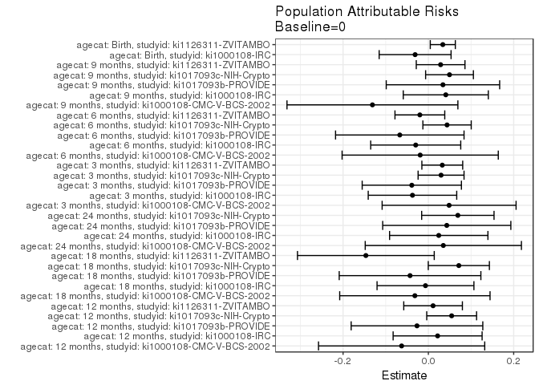

## Data Summary

| agecat | studyid | A | n | nA | nAY0 | nAY1 |
| --- | --- | --- | --- | --- | --- | --- |
| Birth | ki1000108-CMC-V-BCS-2002 | 0 | 90 | 11 | 9 | 2 |
| Birth | ki1000108-CMC-V-BCS-2002 | 1 | 90 | 79 | 65 | 14 |
| Birth | ki1000108-IRC | 0 | 388 | 68 | 58 | 10 |
| Birth | ki1000108-IRC | 1 | 388 | 320 | 285 | 35 |
| Birth | ki1017093b-PROVIDE | 0 | 0 | 0 | 0 | 0 |
| Birth | ki1017093b-PROVIDE | 1 | 0 | 0 | 0 | 0 |
| Birth | ki1017093c-NIH-Crypto | 0 | 19 | 1 | 1 | 0 |
| Birth | ki1017093c-NIH-Crypto | 1 | 19 | 18 | 15 | 3 |
| Birth | ki1066203-TanzaniaChild2 | 0 | 0 | 0 | 0 | 0 |
| Birth | ki1066203-TanzaniaChild2 | 1 | 0 | 0 | 0 | 0 |
| Birth | ki1126311-ZVITAMBO | 0 | 3418 | 288 | 268 | 20 |
| Birth | ki1126311-ZVITAMBO | 1 | 3418 | 3130 | 2797 | 333 |
| 3 months | ki1000108-CMC-V-BCS-2002 | 0 | 362 | 25 | 20 | 5 |
| 3 months | ki1000108-CMC-V-BCS-2002 | 1 | 362 | 337 | 252 | 85 |
| 3 months | ki1000108-IRC | 0 | 407 | 69 | 51 | 18 |
| 3 months | ki1000108-IRC | 1 | 407 | 338 | 265 | 73 |
| 3 months | ki1017093b-PROVIDE | 0 | 168 | 38 | 32 | 6 |
| 3 months | ki1017093b-PROVIDE | 1 | 168 | 130 | 116 | 14 |
| 3 months | ki1017093c-NIH-Crypto | 0 | 471 | 193 | 159 | 34 |
| 3 months | ki1017093c-NIH-Crypto | 1 | 471 | 278 | 215 | 63 |
| 3 months | ki1066203-TanzaniaChild2 | 0 | 573 | 43 | 39 | 4 |
| 3 months | ki1066203-TanzaniaChild2 | 1 | 573 | 530 | 495 | 35 |
| 3 months | ki1126311-ZVITAMBO | 0 | 2251 | 201 | 173 | 28 |
| 3 months | ki1126311-ZVITAMBO | 1 | 2251 | 2050 | 1691 | 359 |
| 6 months | ki1000108-CMC-V-BCS-2002 | 0 | 369 | 25 | 17 | 8 |
| 6 months | ki1000108-CMC-V-BCS-2002 | 1 | 369 | 344 | 241 | 103 |
| 6 months | ki1000108-IRC | 0 | 407 | 69 | 50 | 19 |
| 6 months | ki1000108-IRC | 1 | 407 | 338 | 257 | 81 |
| 6 months | ki1017093b-PROVIDE | 0 | 153 | 32 | 24 | 8 |
| 6 months | ki1017093b-PROVIDE | 1 | 153 | 121 | 101 | 20 |

[output cut: 54 more lines]

## Results Table

### Parameter: TSM

| agecat | studyid | intervention_level | baseline_level | estimate | ci_lower | ci_upper |
| --- | --- | --- | --- | --- | --- | --- |
| Birth | ki1000108-IRC | 0 | NA | 0.1470588 | 0.0627721 | 0.2313455 |
| Birth | ki1000108-IRC | 1 | NA | 0.1093750 | 0.0751345 | 0.1436155 |
| Birth | ki1126311-ZVITAMBO | 0 | NA | 0.0694444 | 0.0400811 | 0.0988078 |
| Birth | ki1126311-ZVITAMBO | 1 | NA | 0.1063898 | 0.0955863 | 0.1171933 |
| 3 months | ki1000108-CMC-V-BCS-2002 | 0 | NA | 0.2000000 | 0.0429859 | 0.3570141 |
| 3 months | ki1000108-CMC-V-BCS-2002 | 1 | NA | 0.2522255 | 0.2057939 | 0.2986571 |
| 3 months | ki1000108-IRC | 0 | NA | 0.2608696 | 0.1571334 | 0.3646057 |
| 3 months | ki1000108-IRC | 1 | NA | 0.2159763 | 0.1720534 | 0.2598993 |
| 3 months | ki1017093b-PROVIDE | 0 | NA | 0.1578947 | 0.0416108 | 0.2741787 |
| 3 months | ki1017093b-PROVIDE | 1 | NA | 0.1076923 | 0.0542454 | 0.1611392 |
| 3 months | ki1017093c-NIH-Crypto | 0 | NA | 0.1761658 | 0.1223622 | 0.2299694 |
| 3 months | ki1017093c-NIH-Crypto | 1 | NA | 0.2266187 | 0.1773544 | 0.2758830 |
| 3 months | ki1126311-ZVITAMBO | 0 | NA | 0.1393035 | 0.0914237 | 0.1871833 |
| 3 months | ki1126311-ZVITAMBO | 1 | NA | 0.1751220 | 0.1586656 | 0.1915783 |
| 6 months | ki1000108-CMC-V-BCS-2002 | 0 | NA | 0.3200000 | 0.1368964 | 0.5031036 |
| 6 months | ki1000108-CMC-V-BCS-2002 | 1 | NA | 0.2994186 | 0.2509538 | 0.3478835 |
| 6 months | ki1000108-IRC | 0 | NA | 0.2753623 | 0.1698337 | 0.3808910 |
| 6 months | ki1000108-IRC | 1 | NA | 0.2396450 | 0.1940816 | 0.2852084 |
| 6 months | ki1017093b-PROVIDE | 0 | NA | 0.2500000 | 0.0994788 | 0.4005212 |
| 6 months | ki1017093b-PROVIDE | 1 | NA | 0.1652893 | 0.0988890 | 0.2316895 |
| 6 months | ki1017093c-NIH-Crypto | 0 | NA | 0.1925134 | 0.1359414 | 0.2490853 |
| 6 months | ki1017093c-NIH-Crypto | 1 | NA | 0.2666667 | 0.2138614 | 0.3194719 |
| 6 months | ki1126311-ZVITAMBO | 0 | NA | 0.1834320 | 0.1250680 | 0.2417960 |
| 6 months | ki1126311-ZVITAMBO | 1 | NA | 0.1616702 | 0.1449713 | 0.1783692 |
| 9 months | ki1000108-CMC-V-BCS-2002 | 0 | NA | 0.5000000 | 0.2996882 | 0.7003118 |
| 9 months | ki1000108-CMC-V-BCS-2002 | 1 | NA | 0.3596491 | 0.3087187 | 0.4105796 |
| 9 months | ki1000108-IRC | 0 | NA | 0.2318841 | 0.1321814 | 0.3315867 |
| 9 months | ki1000108-IRC | 1 | NA | 0.2810651 | 0.2330838 | 0.3290464 |
| 9 months | ki1017093b-PROVIDE | 0 | NA | 0.2000000 | 0.0670609 | 0.3329391 |
| 9 months | ki1017093b-PROVIDE | 1 | NA | 0.2439024 | 0.1677697 | 0.3200351 |
| 9 months | ki1017093c-NIH-Crypto | 0 | NA | 0.1837838 | 0.1279108 | 0.2396567 |
| 9 months | ki1017093c-NIH-Crypto | 1 | NA | 0.2679245 | 0.2145428 | 0.3213062 |
| 9 months | ki1126311-ZVITAMBO | 0 | NA | 0.1656442 | 0.1085582 | 0.2227301 |
| 9 months | ki1126311-ZVITAMBO | 1 | NA | 0.1969782 | 0.1785335 | 0.2154228 |
| 12 months | ki1000108-CMC-V-BCS-2002 | 0 | NA | 0.5600000 | 0.3651550 | 0.7548450 |
| 12 months | ki1000108-CMC-V-BCS-2002 | 1 | NA | 0.4927114 | 0.4397309 | 0.5456918 |
| 12 months | ki1000108-IRC | 0 | NA | 0.2714286 | 0.1671252 | 0.3757320 |
| 12 months | ki1000108-IRC | 1 | NA | 0.2976190 | 0.2486715 | 0.3465666 |
| 12 months | ki1017093b-PROVIDE | 0 | NA | 0.3142857 | 0.1599836 | 0.4685878 |
| 12 months | ki1017093b-PROVIDE | 1 | NA | 0.2796610 | 0.1984125 | 0.3609095 |
| 12 months | ki1017093c-NIH-Crypto | 0 | NA | 0.2054054 | 0.1471248 | 0.2636860 |
| 12 months | ki1017093c-NIH-Crypto | 1 | NA | 0.2981132 | 0.2429776 | 0.3532488 |
| 12 months | ki1126311-ZVITAMBO | 0 | NA | 0.2253521 | 0.1566112 | 0.2940931 |
| 12 months | ki1126311-ZVITAMBO | 1 | NA | 0.2373868 | 0.2161713 | 0.2586023 |
| 18 months | ki1000108-CMC-V-BCS-2002 | 0 | NA | 0.7200000 | 0.5437567 | 0.8962433 |
| 18 months | ki1000108-CMC-V-BCS-2002 | 1 | NA | 0.6860465 | 0.6369368 | 0.7351562 |
| 18 months | ki1000108-IRC | 0 | NA | 0.3623188 | 0.2487635 | 0.4758742 |
| 18 months | ki1000108-IRC | 1 | NA | 0.3541667 | 0.3029656 | 0.4053678 |
| 18 months | ki1017093b-PROVIDE | 0 | NA | 0.4117647 | 0.2457471 | 0.5777824 |
| 18 months | ki1017093b-PROVIDE | 1 | NA | 0.3551402 | 0.2641417 | 0.4461387 |
| 18 months | ki1017093c-NIH-Crypto | 0 | NA | 0.2733333 | 0.2019185 | 0.3447482 |
| 18 months | ki1017093c-NIH-Crypto | 1 | NA | 0.3913043 | 0.3281485 | 0.4544602 |
| 18 months | ki1126311-ZVITAMBO | 0 | NA | 0.6285714 | 0.4683021 | 0.7888408 |
| 18 months | ki1126311-ZVITAMBO | 1 | NA | 0.4685864 | 0.4184851 | 0.5186877 |
| 24 months | ki1000108-CMC-V-BCS-2002 | 0 | NA | 0.6800000 | 0.4968984 | 0.8631016 |
| 24 months | ki1000108-CMC-V-BCS-2002 | 1 | NA | 0.7175793 | 0.6701495 | 0.7650090 |
| 24 months | ki1000108-IRC | 0 | NA | 0.3913043 | 0.2760088 | 0.5065999 |
| 24 months | ki1000108-IRC | 1 | NA | 0.4205882 | 0.3680516 | 0.4731249 |
| 24 months | ki1017093b-PROVIDE | 0 | NA | 0.2857143 | 0.1355460 | 0.4358826 |
| 24 months | ki1017093b-PROVIDE | 1 | NA | 0.3421053 | 0.2547245 | 0.4294861 |
| 24 months | ki1017093c-NIH-Crypto | 0 | NA | 0.2424242 | 0.1578441 | 0.3270044 |
| 24 months | ki1017093c-NIH-Crypto | 1 | NA | 0.3540373 | 0.2800256 | 0.4280489 |

### Parameter: E(Y)

| agecat | studyid | intervention_level | baseline_level | estimate | ci_lower | ci_upper |
| --- | --- | --- | --- | --- | --- | --- |
| Birth | ki1000108-IRC | NA | NA | 0.1159794 | 0.1145520 | 0.1174068 |
| Birth | ki1126311-ZVITAMBO | NA | NA | 0.1032768 | 0.1029327 | 0.1036209 |
| 3 months | ki1000108-CMC-V-BCS-2002 | NA | NA | 0.2486188 | 0.2472528 | 0.2499848 |
| 3 months | ki1000108-IRC | NA | NA | 0.2235872 | 0.2219487 | 0.2252258 |
| 3 months | ki1017093b-PROVIDE | NA | NA | 0.1190476 | 0.1158622 | 0.1222331 |
| 3 months | ki1017093c-NIH-Crypto | NA | NA | 0.2059448 | 0.2037016 | 0.2081880 |
| 3 months | ki1126311-ZVITAMBO | NA | NA | 0.1719236 | 0.1715015 | 0.1723456 |
| 6 months | ki1000108-CMC-V-BCS-2002 | NA | NA | 0.3008130 | 0.3002845 | 0.3013415 |
| 6 months | ki1000108-IRC | NA | NA | 0.2457002 | 0.2443966 | 0.2470039 |
| 6 months | ki1017093b-PROVIDE | NA | NA | 0.1830065 | 0.1775296 | 0.1884835 |
| 6 months | ki1017093c-NIH-Crypto | NA | NA | 0.2363239 | 0.2329774 | 0.2396703 |
| 6 months | ki1126311-ZVITAMBO | NA | NA | 0.1634757 | 0.1632150 | 0.1637364 |
| 9 months | ki1000108-CMC-V-BCS-2002 | NA | NA | 0.3688525 | 0.3652883 | 0.3724166 |
| 9 months | ki1000108-IRC | NA | NA | 0.2727273 | 0.2709322 | 0.2745223 |
| 9 months | ki1017093b-PROVIDE | NA | NA | 0.2341772 | 0.2313254 | 0.2370290 |
| 9 months | ki1017093c-NIH-Crypto | NA | NA | 0.2333333 | 0.2295040 | 0.2371627 |
| 9 months | ki1126311-ZVITAMBO | NA | NA | 0.1943590 | 0.1939740 | 0.1947440 |
| 12 months | ki1000108-CMC-V-BCS-2002 | NA | NA | 0.4972826 | 0.4955503 | 0.4990149 |
| 12 months | ki1000108-IRC | NA | NA | 0.2931034 | 0.2921399 | 0.2940670 |
| 12 months | ki1017093b-PROVIDE | NA | NA | 0.2875817 | 0.2852697 | 0.2898937 |
| 12 months | ki1017093c-NIH-Crypto | NA | NA | 0.2600000 | 0.2557807 | 0.2642193 |
| 12 months | ki1126311-ZVITAMBO | NA | NA | 0.2363744 | 0.2362150 | 0.2365338 |
| 18 months | ki1000108-CMC-V-BCS-2002 | NA | NA | 0.6883469 | 0.6874751 | 0.6892187 |
| 18 months | ki1000108-IRC | NA | NA | 0.3555556 | 0.3552567 | 0.3558544 |
| 18 months | ki1017093b-PROVIDE | NA | NA | 0.3687943 | 0.3647820 | 0.3728067 |
| 18 months | ki1017093c-NIH-Crypto | NA | NA | 0.3447368 | 0.3389315 | 0.3505422 |
| 18 months | ki1126311-ZVITAMBO | NA | NA | 0.4820144 | 0.4777514 | 0.4862773 |
| 24 months | ki1000108-CMC-V-BCS-2002 | NA | NA | 0.7150538 | 0.7140963 | 0.7160112 |
| 24 months | ki1000108-IRC | NA | NA | 0.4156479 | 0.4145838 | 0.4167120 |
| 24 months | ki1017093b-PROVIDE | NA | NA | 0.3288591 | 0.3250076 | 0.3327105 |
| 24 months | ki1017093c-NIH-Crypto | NA | NA | 0.3115385 | 0.3049381 | 0.3181389 |

### Parameter: RR

| agecat | studyid | intervention_level | baseline_level | estimate | ci_lower | ci_upper |
| --- | --- | --- | --- | --- | --- | --- |
| Birth | ki1000108-IRC | 1 | 0 | 0.7437500 | 0.3870802 | 1.429068 |
| Birth | ki1126311-ZVITAMBO | 1 | 0 | 1.5320128 | 0.9917620 | 2.366559 |
| 3 months | ki1000108-CMC-V-BCS-2002 | 1 | 0 | 1.2611276 | 0.5630659 | 2.824612 |
| 3 months | ki1000108-IRC | 1 | 0 | 0.8279093 | 0.5296742 | 1.294067 |
| 3 months | ki1017093b-PROVIDE | 1 | 0 | 0.6820513 | 0.2806264 | 1.657698 |
| 3 months | ki1017093c-NIH-Crypto | 1 | 0 | 1.2863944 | 0.8842302 | 1.871470 |
| 3 months | ki1126311-ZVITAMBO | 1 | 0 | 1.2571254 | 0.8802974 | 1.795262 |
| 6 months | ki1000108-CMC-V-BCS-2002 | 1 | 0 | 0.9356831 | 0.5162674 | 1.695832 |
| 6 months | ki1000108-IRC | 1 | 0 | 0.8702896 | 0.5673744 | 1.334928 |
| 6 months | ki1017093b-PROVIDE | 1 | 0 | 0.6611570 | 0.3205991 | 1.363474 |
| 6 months | ki1017093c-NIH-Crypto | 1 | 0 | 1.3851852 | 0.9718846 | 1.974245 |
| 6 months | ki1126311-ZVITAMBO | 1 | 0 | 0.8813634 | 0.6307733 | 1.231507 |
| 9 months | ki1000108-CMC-V-BCS-2002 | 1 | 0 | 0.7192982 | 0.4702952 | 1.100139 |
| 9 months | ki1000108-IRC | 1 | 0 | 1.2120932 | 0.7631745 | 1.925077 |
| 9 months | ki1017093b-PROVIDE | 1 | 0 | 1.2195122 | 0.5851493 | 2.541591 |
| 9 months | ki1017093c-NIH-Crypto | 1 | 0 | 1.4578246 | 1.0135504 | 2.096840 |
| 9 months | ki1126311-ZVITAMBO | 1 | 0 | 1.1891645 | 0.8320410 | 1.699571 |
| 12 months | ki1000108-CMC-V-BCS-2002 | 1 | 0 | 0.8798417 | 0.6112877 | 1.266378 |
| 12 months | ki1000108-IRC | 1 | 0 | 1.0964912 | 0.7218953 | 1.665467 |
| 12 months | ki1017093b-PROVIDE | 1 | 0 | 0.8898305 | 0.5029801 | 1.574214 |
| 12 months | ki1017093c-NIH-Crypto | 1 | 0 | 1.4513406 | 1.0343748 | 2.036389 |
| 12 months | ki1126311-ZVITAMBO | 1 | 0 | 1.0534039 | 0.7665665 | 1.447572 |
| 18 months | ki1000108-CMC-V-BCS-2002 | 1 | 0 | 0.9528424 | 0.7383478 | 1.229649 |
| 18 months | ki1000108-IRC | 1 | 0 | 0.9775000 | 0.6921827 | 1.380425 |
| 18 months | ki1017093b-PROVIDE | 1 | 0 | 0.8624833 | 0.5349099 | 1.390659 |
| 18 months | ki1017093c-NIH-Crypto | 1 | 0 | 1.4316013 | 1.0530478 | 1.946239 |
| 18 months | ki1126311-ZVITAMBO | 1 | 0 | 0.7454783 | 0.5654047 | 0.982903 |
| 24 months | ki1000108-CMC-V-BCS-2002 | 1 | 0 | 1.0552636 | 0.7997388 | 1.392431 |
| 24 months | ki1000108-IRC | 1 | 0 | 1.0748366 | 0.7804693 | 1.480230 |
| 24 months | ki1017093b-PROVIDE | 1 | 0 | 1.1973684 | 0.6674840 | 2.147903 |
| 24 months | ki1017093c-NIH-Crypto | 1 | 0 | 1.4604037 | 0.9723728 | 2.193376 |

### Parameter: PAR

| agecat | studyid | intervention_level | baseline_level | estimate | ci_lower | ci_upper |
| --- | --- | --- | --- | --- | --- | --- |
| Birth | ki1000108-IRC | 0 | NA | -0.0310794 | -0.1153782 | 0.0532194 |
| Birth | ki1126311-ZVITAMBO | 0 | NA | 0.0338323 | 0.0044670 | 0.0631977 |
| 3 months | ki1000108-CMC-V-BCS-2002 | 0 | NA | 0.0486188 | -0.1084013 | 0.2056389 |
| 3 months | ki1000108-IRC | 0 | NA | -0.0372823 | -0.1410314 | 0.0664667 |
| 3 months | ki1017093b-PROVIDE | 0 | NA | -0.0388471 | -0.1551747 | 0.0774804 |
| 3 months | ki1017093c-NIH-Crypto | 0 | NA | 0.0297790 | -0.0240714 | 0.0836294 |
| 3 months | ki1126311-ZVITAMBO | 0 | NA | 0.0326201 | -0.0152616 | 0.0805018 |
| 6 months | ki1000108-CMC-V-BCS-2002 | 0 | NA | -0.0191870 | -0.2022913 | 0.1639173 |
| 6 months | ki1000108-IRC | 0 | NA | -0.0296621 | -0.1351988 | 0.0758746 |
| 6 months | ki1017093b-PROVIDE | 0 | NA | -0.0669935 | -0.2176143 | 0.0836273 |
| 6 months | ki1017093c-NIH-Crypto | 0 | NA | 0.0438105 | -0.0128603 | 0.1004813 |
| 6 months | ki1126311-ZVITAMBO | 0 | NA | -0.0199563 | -0.0783209 | 0.0384083 |
| 9 months | ki1000108-CMC-V-BCS-2002 | 0 | NA | -0.1311475 | -0.3314911 | 0.0691960 |
| 9 months | ki1000108-IRC | 0 | NA | 0.0408432 | -0.0588756 | 0.1405620 |
| 9 months | ki1017093b-PROVIDE | 0 | NA | 0.0341772 | -0.0987925 | 0.1671469 |
| 9 months | ki1017093c-NIH-Crypto | 0 | NA | 0.0495495 | -0.0064545 | 0.1055536 |
| 9 months | ki1126311-ZVITAMBO | 0 | NA | 0.0287148 | -0.0283725 | 0.0858021 |
| 12 months | ki1000108-CMC-V-BCS-2002 | 0 | NA | -0.0627174 | -0.2575701 | 0.1321353 |
| 12 months | ki1000108-IRC | 0 | NA | 0.0216749 | -0.0826330 | 0.1259827 |
| 12 months | ki1017093b-PROVIDE | 0 | NA | -0.0267040 | -0.1810235 | 0.1276154 |
| 12 months | ki1017093c-NIH-Crypto | 0 | NA | 0.0545946 | -0.0038385 | 0.1130277 |
| 12 months | ki1126311-ZVITAMBO | 0 | NA | 0.0110223 | -0.0577188 | 0.0797634 |
| 18 months | ki1000108-CMC-V-BCS-2002 | 0 | NA | -0.0316531 | -0.2078986 | 0.1445923 |
| 18 months | ki1000108-IRC | 0 | NA | -0.0067633 | -0.1203190 | 0.1067925 |
| 18 months | ki1017093b-PROVIDE | 0 | NA | -0.0429704 | -0.2090365 | 0.1230958 |
| 18 months | ki1017093c-NIH-Crypto | 0 | NA | 0.0714035 | -0.0002469 | 0.1430539 |
| 18 months | ki1126311-ZVITAMBO | 0 | NA | -0.1465570 | -0.3068830 | 0.0137690 |
| 24 months | ki1000108-CMC-V-BCS-2002 | 0 | NA | 0.0350538 | -0.1480503 | 0.2181578 |
| 24 months | ki1000108-IRC | 0 | NA | 0.0243436 | -0.0909569 | 0.1396440 |
| 24 months | ki1017093b-PROVIDE | 0 | NA | 0.0431448 | -0.1070729 | 0.1933625 |
| 24 months | ki1017093c-NIH-Crypto | 0 | NA | 0.0691142 | -0.0157231 | 0.1539515 |

### Parameter: PAF

| agecat | studyid | intervention_level | baseline_level | estimate | ci_lower | ci_upper |
| --- | --- | --- | --- | --- | --- | --- |
| Birth | ki1000108-IRC | 0 | NA | -0.2679739 | -1.2494865 | 0.2852779 |
| Birth | ki1126311-ZVITAMBO | 0 | NA | 0.3275889 | -0.0262996 | 0.5594496 |
| 3 months | ki1000108-CMC-V-BCS-2002 | 0 | NA | 0.1955556 | -0.7638282 | 0.6331100 |
| 3 months | ki1000108-IRC | 0 | NA | -0.1667463 | -0.7366215 | 0.2161234 |
| 3 months | ki1017093b-PROVIDE | 0 | NA | -0.3263158 | -1.7714090 | 0.3652638 |
| 3 months | ki1017093c-NIH-Crypto | 0 | NA | 0.1445970 | -0.1611680 | 0.3698463 |
| 3 months | ki1126311-ZVITAMBO | 0 | NA | 0.1897361 | -0.1426182 | 0.4254182 |
| 6 months | ki1000108-CMC-V-BCS-2002 | 0 | NA | -0.0637838 | -0.8851992 | 0.3997261 |
| 6 months | ki1000108-IRC | 0 | NA | -0.1207246 | -0.6441900 | 0.2360836 |
| 6 months | ki1017093b-PROVIDE | 0 | NA | -0.3660714 | -1.4961940 | 0.2524014 |
| 6 months | ki1017093c-NIH-Crypto | 0 | NA | 0.1853832 | -0.0932591 | 0.3930072 |
| 6 months | ki1126311-ZVITAMBO | 0 | NA | -0.1220749 | -0.5424336 | 0.1837237 |
| 9 months | ki1000108-CMC-V-BCS-2002 | 0 | NA | -0.3555556 | -1.0237486 | 0.0920162 |
| 9 months | ki1000108-IRC | 0 | NA | 0.1497585 | -0.3070636 | 0.4469201 |
| 9 months | ki1017093b-PROVIDE | 0 | NA | 0.1459459 | -0.6603797 | 0.5606979 |
| 9 months | ki1017093c-NIH-Crypto | 0 | NA | 0.2123552 | -0.0679587 | 0.4190934 |
| 9 months | ki1126311-ZVITAMBO | 0 | NA | 0.1477411 | -0.2029429 | 0.3961930 |
| 12 months | ki1000108-CMC-V-BCS-2002 | 0 | NA | -0.1261202 | -0.5947760 | 0.2048120 |
| 12 months | ki1000108-IRC | 0 | NA | 0.0739496 | -0.3599706 | 0.3694207 |
| 12 months | ki1017093b-PROVIDE | 0 | NA | -0.0928571 | -0.7857217 | 0.3311742 |
| 12 months | ki1017093c-NIH-Crypto | 0 | NA | 0.2099792 | -0.0496977 | 0.4054166 |
| 12 months | ki1126311-ZVITAMBO | 0 | NA | 0.0466307 | -0.2934148 | 0.2972764 |
| 18 months | ki1000108-CMC-V-BCS-2002 | 0 | NA | -0.0459843 | -0.3360853 | 0.1811279 |
| 18 months | ki1000108-IRC | 0 | NA | -0.0190217 | -0.3941111 | 0.2551488 |
| 18 months | ki1017093b-PROVIDE | 0 | NA | -0.1165158 | -0.6712059 | 0.2540670 |
| 18 months | ki1017093c-NIH-Crypto | 0 | NA | 0.2071247 | -0.0301730 | 0.3897614 |
| 18 months | ki1126311-ZVITAMBO | 0 | NA | -0.3040512 | -0.6830422 | -0.0104022 |
| 24 months | ki1000108-CMC-V-BCS-2002 | 0 | NA | 0.0490226 | -0.2448380 | 0.2735134 |
| 24 months | ki1000108-IRC | 0 | NA | 0.0585678 | -0.2640267 | 0.2988323 |
| 24 months | ki1017093b-PROVIDE | 0 | NA | 0.1311953 | -0.4697357 | 0.4864236 |
| 24 months | ki1017093c-NIH-Crypto | 0 | NA | 0.2218481 | -0.1037375 | 0.4513910 |